# Notebook 14: Example Third Projects - Montréal and Urbana-Champaign

I thought it would be useful to show a few examples of things that could be the focus of a presentation for Project 3, using two different cities: Montréal and Urbana-Champaign. Urbana-Champaign is quite a bit smaller than the projects you have in class and I think is more difficult to find something interesting. Montréal on the other hand is significantly more complex due to the use of French and English in the reviews; there is a lot there, but I thought it may be too complex given the short time line.

Each of the three sections below are a good guide to the number of tables and plots individual project probably should be. Yes, perhaps you would add a few more examples, but use the sections as a guide for how large a scope you should be trying to capture with your work.

The three examples cover the following topics:

1. The use of French and English in Montréal reviews.
2. The effect of location in the Urbana-Champaign reviews.
3. Gender in reviews from Urbana-Champaign.

Note that I tried to focus on thing that extend what I had already done in the notes to show what is possible. If your project focuses more on the methods in Notebook 13, that will not be a problem. However, if you want to do something a bit different, I of course encourage that as well!

# 1. Montreal/Montréal: French and English

I will start by reading in the yelp data for Montréal:

```r
yelp <- read_csv("data/montreal.csv.gz")
token <- read_csv("data/montreal_token.csv.gz")
```

And then, store and plot the three clusters that appear in the PCA components of the TF matrix:

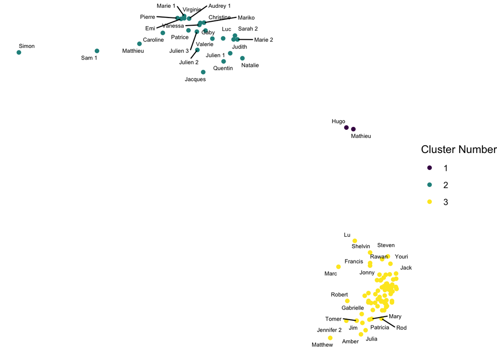

```r
set.seed(5)
clusters <- token %>%
  cnlp_utils_tf(
    doc_set = unique(yelp$user_name),
    min_df = 0.001,
    max_df = 1.0,
    max_features = 10000,
    doc_var = "user_name",
    token_var = "token"
  ) %>%
  sm_tidy_pca(n = 2) %>%
  sm_kmeans(clusters = 3)

clusters %>%
  ggplot(aes(x = v1, y = v2)) +
    geom_point(aes(color = factor(cluster))) +
    geom_text_repel(
      aes(label = document),
      show.legend = FALSE,
      max.overlaps = 20,
      size = 2
    ) +
    labs(color = "Cluster Number") +
    scale_color_viridis_d() +
    theme_void()
```

Notice that there is a strong clustering here (you likely do not have anything as strong in the cities that I gave to use for class). Looking at the TF-IDF terms as a function of cluster sheds some light on what is going on:

```r
token %>%
  filter(upos == "NOUN") %>%
  sm_text_tfidf(doc_var = "user_name", token_var = "lemma") %>%
  group_by(doc_id) %>%
  arrange(desc(tfidf)) %>%
  slice_head(n = 5) %>%
  summarize(tokens = paste(token, collapse = "; ")) %>%
  left_join(select(clusters, document, cluster), by = c("doc_id" = "document")) %>%
  arrange(cluster) %>%
  print.data.frame()
```

```
##          doc_id                                              tokens cluster
## 1          Hugo                  profiterole; une; un; boeuf; oeufs       1
## 2       Mathieu                            allé; payé; que; un; une       1
## 3      Audrey 1                  que; glacée; également; saveur; je       2
## 4      Caroline                 volonté; une; sympa; livraison; bon       2
## 5     Christine                     une; un; pour; pâtisserie; cela       2
## 6           Emi                   une; un; évidemment; propose; que       2
## 7          Gaby                     bref; que; je; fille; proximité       2
## 8       Jacques               facile; professionnel; fumée; une; un       2
## 9        Judith                     que; réservation; une; un; pour       2
## 10     Julien 1 déjeuner; copine; professionnel; gratuit; abordable       2
## 11     Julien 2          sont; bonne; moyenne; magasin; l'intérieur       2
## 12     Julien 3              également; offre; cependant; vrac; que       2
## 13          Luc               critique; correcte; offre; ici; fumée       2
## 14      Marie 1                            allée; que; qui; un; une       2
```

[output cut: 86 more lines]

The reviews in cluster 2 are in French and those in cluster 3 are in English. Cluster 1 consists of only two people; the top TF-IDF words are in French, but what is actually going on? Looking at some example texts, Hugo kindly provides his reviews in both languages:

```r
set.seed(1)
yelp %>%
  filter(user_name == "Hugo") %>%
  sample_n(size = 4) %>%
  use_series(text)
```

```
## [1] "Jeudi 24 octobre 2013 Une belle fin de journée, après ClasseTechno. On décide de se rendre au Pub Victoria pour se retrouver entre amis. En entrant, on reconnait le pub typique, un peu sombre, très très bruyant, plus ou moins occupé mais en plein remplissage du jeudi. Si vous ne savez pas tr…
## [2] "Le magasin où on trouve pas mal tout ce dont on a besoin en matière de réno, travaux, jardin, etc... J'aime bien y aller pour voir les nouveautés en outillages ou même les derniers produits de rangement. Les prix ne sont pas toujours les meilleurs mais comme j'habite dans les environs, c'est…
## [3] "Katz est un petit comptoir et un restaurant de plein pied, à l'intérieur de la Place Ville-Marie. J'y suis un occasionnel lorsque je veux un smoked meat sans avoir à me rendre sur St-Laurent, chez Schwartz. Comme Ben's est fermé depuis 2006 (snif snif !), c'est peut-être le seul déli du cent…
## [4] "6 janvier 2013 Retour chez Juliette et Chocolat. La dernière fois c'était pour des chocolats au comptoir. C'était très bien, les chocolats sont extraordinaires (5 ÉTOILES) mais comme ils ont voulu allier le concept service-resto et chocolaterie-pâtisserie, ils ont oublié de maîtriser les deu…
```

Whereas Mathieu switches between reviews (it’s not clear why, but would be a good deep dive to look into); in one case he also translates the review, but this is not as common.

```r
set.seed(1)
yelp %>%
  filter(user_name == "Mathieu") %>%
  sample_n(size = 4) %>%
  use_series(text)
```

```
## [1] "Yup, 5 stars! That place is awesome, as some previous yelpers wrote, they have this 22$ meal (appetizer + main course) (and not 3 courses as mention in another post). It's quite a big place, not that easy to see it. You need to know where it is otherwise, you might pass in front without noti…
## [2] "Je ne sais pas trop quoi dire de cet endroit.  La bouffe est extrêmement bonne! C'est excellent. Il s'agit d'un bar à vin avec des bières micros et locale pas cher. La clientèle est diverse. Un moment, c'est 25-30 ans et puis l'ambiance change et devient un bar de 35 ans et plus. C'est vraim…
## [3] "Je reviendrais sans réfléchir a Zéro 8. Le nom est original, c'est que les 8 principaux allergènes y sont banni! Le mot banni semble cruel? Bah! C'est simplement qu'on a tous des amis cher a nous qu'on doit faire des pieds et des mains pour invité a manger chez soi Éviter des pièges complexe…
## [4] "Wohoo, Sales! This is not the biggest strenght of MEC, of course, but when it happen, it's not that much advertised but if you're looking at the right place, at the right momen, you're golden! MEC is most likely one of my favorite place to shop. In my top 4 for sure. I like books,music, trav…
```

Using the clusters we can see the relative popularity of each business type based on the clusters. Brasseries and cafés are particularly popular with Francophone reviewers; Burgers, Greek, and Chinese are popular with Anglophone reviewers. Interestingly, there are a lot of reviews for French restaurants, but these are evenly distributed between the two groups.

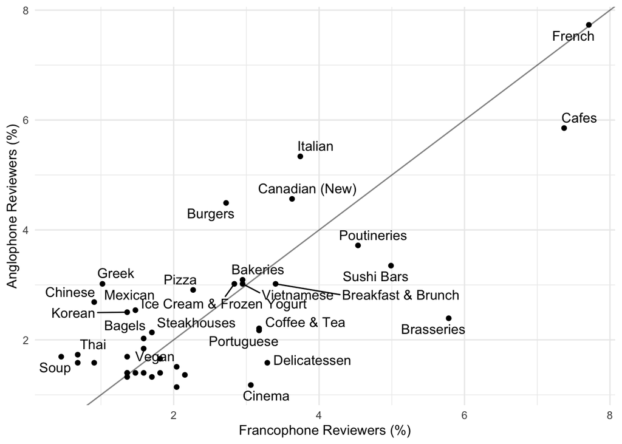

```r
yelp %>%
  left_join(clusters, by = c("user_name" = "document")) %>%
  filter(biz_category != "Other") %>%
  group_by(biz_category, cluster) %>%
  summarize(n = n()) %>%
  ungroup() %>%
  pivot_wider(
    id_cols = c(biz_category),
    names_from = cluster,
    values_from = n,
    names_prefix = "cluster_",
    names_sort = TRUE
  ) %>%
  mutate(
    cluster_2 = cluster_2 / sum(cluster_2) * 100,
    cluster_3 = cluster_3 / sum(cluster_3) * 100
  ) %>%
  ggplot(aes(cluster_2, cluster_3)) +
    geom_abline(alpha = 0.5) +
    geom_point() +
    geom_text_repel(aes(label = biz_category)) +
    labs(x = "Francophone Reviewers (%)", y = "Anglophone Reviewers (%)")
```

Of course, you likely won’t have as strong a single in your dataset. But this would not stop you from clustering in a similar way and doing a similar analysis.

# 2. Location in Urbana-Champaign

As a second example, let’s grab the Yelp data from Urbana-Champaign.

```r
yelp <- read_csv("data/urbana-champaign.csv.gz")
token <- read_csv("data/urbana-champaign_token.csv.gz")
```

We will try to look at the spatial distribution of the data, which we can start doing by running a KMeans clustering algorithm on the longitude and latitude variables.

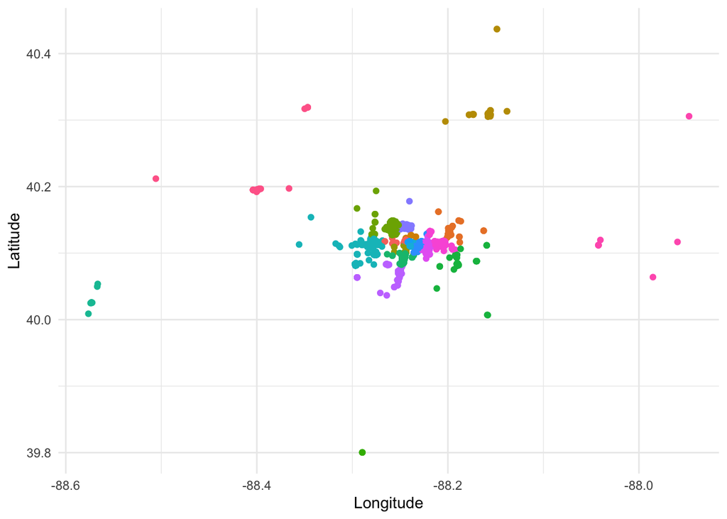

```r
set.seed(5)
clusters <- yelp %>%
  select(doc_id, lon, lat) %>%
  sm_kmeans(clusters = 20, item_name = "doc_id") %>%
  select(-lon, -lat)

yelp %>%
  left_join(clusters, by = "doc_id") %>%
  ggplot(aes(lon, lat)) +
    geom_point(aes(color = factor(cluster)), show.legend = FALSE) +
    labs(x = "Longitude", y = "Latitude", color = "Cluster ID")
```

Not super interesting on its own, but we can use these clusters as grouping variables. Several of these are interesting:

```r
token %>%
  filter(upos == "NOUN") %>%
  left_join(clusters, by = "doc_id") %>%
  sm_text_tfidf(doc_var = "cluster", token_var = "lemma") %>%
  group_by(doc_id) %>%
  arrange(desc(tfidf)) %>%
  slice_head(n = 8) %>%
  summarize(tokens = paste(token, collapse = "; ")) %>%
  print.data.frame()
```

```
##    doc_id
## 1       1
## 2       2
## 3       3
## 4       4
## 5       5
## 6       6
## 7       7
## 8       8
## 9       9
## 10     10
## 11     11
## 12     12
## 13     13
## 14     14
```

[output cut: 27 more lines]

One that caught my eye was cluster 14, as it seems to be related to businesses near or related to a University. Let’s plot this cluster specifically over a map; it shows that it is in fact located at the University of Illinois.

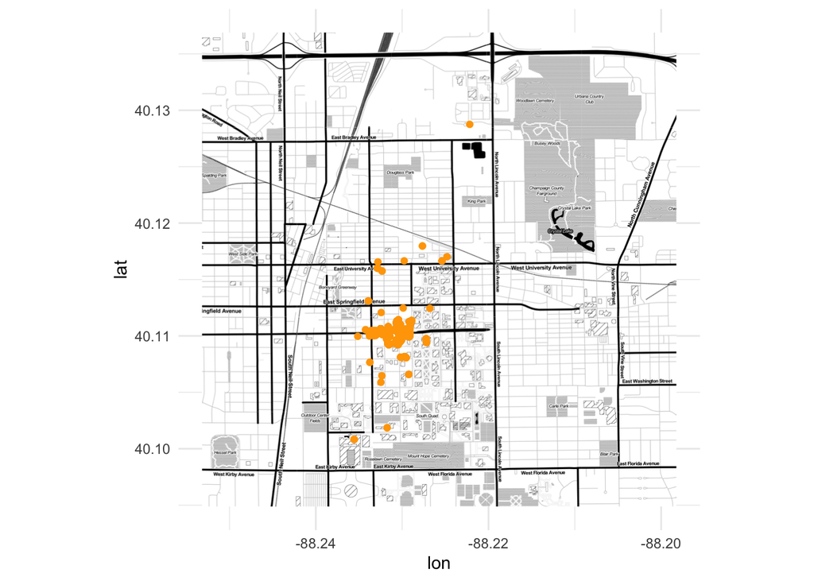

```r
library(ggmaptile)

yelp %>%
  left_join(clusters, by = "doc_id") %>%
  filter(cluster == 14) %>%
  ggplot(aes(lon, lat)) +
    stat_maptiles(aspect_ratio = 1, zoom = 15) +
    geom_point(color = "orange")
```

With this cluster, let’s see who tends to review locations in this area:

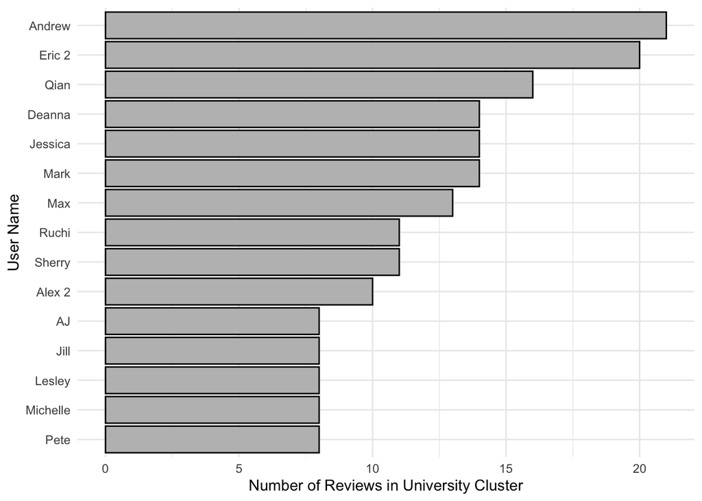

```r
count_cluster_14 <- yelp %>%
  left_join(clusters, by = "doc_id") %>%
  filter(cluster == 14) %>%
  group_by(user_name) %>%
  summarize(n = n()) %>%
  arrange(desc(n))

count_cluster_14 %>%
  slice_head(n = 15) %>%
  mutate(user_name = fct_inorder(user_name)) %>%
  ggplot(aes(fct_rev(user_name), n)) +
    geom_col(color = "black", fill = "grey") +
    coord_flip() +
    labs(x = "User Name", y = "Number of Reviews in University Cluster")
```

Now we can see the tokens these use in these reviews. Do you think these were written by college students?

```r
token %>%
  filter(upos == "NOUN") %>%
  semi_join(filter(clusters, cluster == 14), by = "doc_id") %>%
  sm_text_tfidf(doc_var = "user_name", token_var = "lemma") %>%
  group_by(doc_id) %>%
  arrange(desc(tfidf)) %>%
  slice_head(n = 8) %>%
  summarize(tokens = paste(token, collapse = "; ")) %>%
  left_join(count_cluster_14, by = c("doc_id" = "user_name")) %>%
  filter(n > 6) %>%
  arrange(desc(n)) %>%
  print.data.frame()
```

```
##      doc_id                                                           tokens
## 1    Andrew                 bubble; cream; ice; bowl; deal; bit; dinner; tea
## 2    Eric 2           water; level; bowl; bubble; beef; reason; hour; veggie
## 3      Qian            broth; beef; oil; taste; noodle; bowl; veggie; kimchi
## 4    Deanna              bar; point; type; sushi; deal; table; night; friend
## 5   Jessica              water; %; curry; coffee; end; tofu; floor; employee
## 6      Mark     raman; curry; room; broth; specialty; shop; employee; noodle
## 7       Max              staff; bar; dinner; meal; deal; cheese; lunch; menu
## 8     Ruchi mushroom; vegetable; coffee; dinner; raman; review; sushi; broth
## 9    Sherry            table; hour; part; broth; customer; friend; soup; bit
## 10   Alex 2             tea; coffee; one; bubble; pizza; kind; deal; problem
## 11       AJ                  cream; ice; fan; curry; side; review; bit; town
## 12     Jill              raman; broth; fish; review; bowl; beef; sushi; town
## 13   Lesley          bite; cheese; sandwich; school; fry; class; tea; greasy
## 14 Michelle pizza; college; salad; atmosphere; chicken; fry; chance; lettuce
```

[output cut: 25 more lines]

Urbana-Champaign is quite small compared to the other cities in the collection. My guess is that a similar analysis would turn up even more interesting clusters in larger cities such as Toronto and Las Vegas.

# 3. Predicted User Gender in Urbana-Champaign

As a final example, let’s look at the predicted gender tags. To start, we will actually use some supervised learning but building a model with all lemmas that do not contain capital letters or non-alphanumeric values:

```r
X <- token %>%
  filter(!stri_detect(lemma, regex = "[A-Z\\W]")) %>%
  cnlp_utils_tf(
    doc_set = yelp$doc_id,
    min_df = 0.001,
    max_df = 1.0,
    max_features = 10000,
    doc_var = "doc_id",
    token_var = "lemma"
  )

X_train <- X[yelp$train_id == "train", ]
y_train <- yelp$gender[yelp$train_id == "train"]

model <- cv.glmnet(
  X_train,
  y_train,
  alpha = 0.9,
  family = "multinomial",
  nfolds = 3,
  trace.it = FALSE,
  relax = FALSE,
  lambda.min.ratio = 0.01,
  nlambda = 100
)
```

The classification rate is relatively low given that there are only two categories:

```r
yelp %>%
  mutate(pred = as.vector(predict(model, newx = X, type = "class"))) %>%
  group_by(train_id) %>%
  summarize(class_rate = mean(gender == pred))
```

```
## # A tibble: 2 x 2
##   train_id class_rate
##   <chr>         <dbl>
## 1 train         0.643
## 2 valid         0.601
```

The most predictive words, however, are interesting:

```r
temp <- coef(model, s = model$lambda[14])
beta <- Reduce(cbind, temp)
beta <- beta[apply(beta != 0, 1, any),]
colnames(beta) <- names(temp)
beta
```

```
## 15 x 2 sparse Matrix of class "dgCMatrix"
##                   female         male
## (Intercept) -0.019924156  0.019924156
## good        -0.013792697  0.013792697
## well        -0.006736239  0.006736239
## by           0.002125650 -0.002125650
## love         0.122314364 -0.122314364
## quite       -0.096303760  0.096303760
## nothing     -0.035810019  0.035810019
## husband      0.273691414 -0.273691414
## thank        0.016842015 -0.016842015
## yummy        0.073628033 -0.073628033
## beautiful    0.033104142 -0.033104142
## boyfriend    0.287729536 -0.287729536
## produce      0.031655617 -0.031655617
## wife        -0.103775245  0.103775245
## cute         0.016425657 -0.016425657
```

Now, how can we use this information in an unsupervised fashion. Let’s start by building a data set showing how often an individual’s reviews are classified as “female”:

```r
class_rate <- yelp %>%
  mutate(pred = as.vector(predict(model, newx = X, type = "class"))) %>%
  mutate(prop = as.vector(
    predict(model, newx = X, type = "response")[,,1][,1]
  )) %>%
  group_by(user_name) %>%
  summarize(
    class_rate = mean(gender == pred),
    gender = first(gender),
    perc_female = mean(prop)
  ) %>%
  arrange(perc_female)

class_rate
```

```
## # A tibble: 100 x 4
##    user_name class_rate gender perc_female
##    <chr>          <dbl> <chr>        <dbl>
##  1 John 1         0.857 male         0.407
##  2 Nelson         0.964 male         0.428
##  3 Edward         0.964 male         0.445
##  4 Ken            0.821 male         0.449
##  5 David 2        0.929 male         0.450
##  6 Alex 1         0.893 male         0.453
##  7 Eric 2         0.964 male         0.454
##  8 Patrick        0.964 male         0.464
##  9 Daniel         0.929 male         0.466
## 10 David 1        0.964 male         0.468
## # … with 90 more rows
```

Now, we can use this information provided by a predictive model to help better understand the data using unsupervised tools. For example, what are the top TF-IDF terms for each user, orderd by the average percentage that their reviews are assigned to the “female” category:

```r
token %>%
  filter(upos == "NOUN") %>%
  sm_text_tfidf(doc_var = "user_name", token_var = "lemma") %>%
  group_by(doc_id) %>%
  arrange(desc(tfidf)) %>%
  slice_head(n = 3) %>%      # setting small to show the results
  summarize(tokens = paste(token, collapse = "; ")) %>%
  left_join(
    select(class_rate, user_name, perc_female, gender),
    by = c("doc_id" = "user_name")
  ) %>%
  arrange(perc_female) %>%
  print.data.frame()
```

```
##          doc_id                           tokens perc_female gender
## 1        John 1         wife; request; hamburger   0.4065513   male
## 2        Nelson               pro; tire; protein   0.4282633   male
## 3        Edward         shoe; impression; result   0.4452318   male
## 4           Ken      girlfriend; brewery; yogurt   0.4493711   male
## 5       David 2                  bed; tuna; chop   0.4495470   male
## 6        Alex 1        girlfriend; gyro; lobster   0.4526276   male
## 7        Eric 2               plastic; sub; tray   0.4537507   male
## 8       Patrick                   pet; pan; park   0.4636408   male
## 9        Daniel                bbq; brunch; deli   0.4657687   male
## 10      David 1      cupcake; bourbon; pepperoni   0.4677158   male
## 11          Tim              team; jewelry; band   0.4691253   male
## 12        Steve           band; custard; weekday   0.4700270   male
## 13         Pete        apartment; haircut; study   0.4725809   male
## 14       Kamron               tire; law; burrito   0.4737008   male
```

[output cut: 86 more lines]

We can also look at the relationship between the predicted gender of reviews for each business based on our text analysis relative to the proportion based on the predicted gender based on the name.

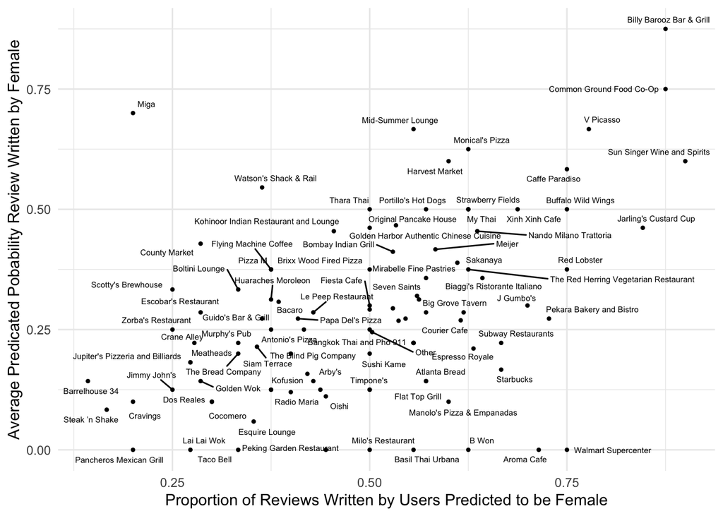

```r
yelp %>%
  mutate(pred = as.vector(predict(model, newx = X, type = "class"))) %>%
  group_by(b_name) %>%
  summarize(prop_female = mean(gender == "female"), prop_female_pred = mean(pred == "female")) %>%
  ggplot(aes(prop_female, prop_female_pred)) +
    geom_point(size = 0.8) +
    geom_text_repel(aes(label = b_name), size = 2) +
    labs(x = "Proportion of Reviews Written by Users Predicted to be Female",
         y = "Average Predicated Pobability Review Written by Female")
```

A lot of women seem to leave reviews at Walmart, but leave relatively masculine reviews when they do. Miga (a sushi restaurant) is the other way around. A lot reviews are left by users tagged as “male”, but the model thinks they contain a lot of feminine language.

The Urbana-Champaign dataset is relatively small. My guess is that you would find some more interesting effects looking at gender on one of the class data sets.